# Doctor Who

2022-01-15

## Explore data

```r
episodes <- readr::read_csv("https://raw.githubusercontent.com/rfordatascience/tidytuesday/master/data/2021/2021-11-23/episodes.csv") %>%
  filter(!is.na(uk_viewers))
episodes
```

| era | season_number | serial_title | story_number | episode_number | episode_title | type | first_aired | production_code | uk_viewers | rating | duration |
| --- | --- | --- | --- | --- | --- | --- | --- | --- | --- | --- | --- |
| revived | 1 | NA | 157 | 1 | Rose | episode | 2005-03-26 | 1.1 | 10.81 | 76 | 45 |
| revived | 1 | NA | 158 | 2 | The End of the World | episode | 2005-04-02 | 1.2 | 7.97 | 76 | 44 |
| revived | 1 | NA | 159 | 3 | The Unquiet Dead | episode | 2005-04-09 | 1.3 | 8.86 | 80 | 44 |
| revived | 1 | NA | 160a | 4 | Aliens of London | episode | 2005-04-16 | 1.4 | 7.63 | 82 | 45 |
| revived | 1 | NA | 160b | 5 | World War Three | episode | 2005-04-23 | 1.5 | 7.98 | 81 | 42 |
| revived | 1 | NA | 161 | 6 | Dalek | episode | 2005-04-30 | 1.6 | 8.63 | 84 | 45 |
| revived | 1 | NA | 162 | 7 | The Long Game | episode | 2005-05-07 | 1.7 | 8.01 | 81 | 44 |
| revived | 1 | NA | 163 | 8 | Father's Day | episode | 2005-05-14 | 1.8 | 8.06 | 83 | 45 |
| revived | 1 | NA | 164a | 9 | The Empty Child | episode | 2005-05-21 | 1.9 | 7.11 | 84 | 45 |
| revived | 1 | NA | 164b | 10 | The Doctor Dances | episode | 2005-05-28 | 1.1 | 6.86 | 85 | 45 |

[output cut: 157 more lines]

uk_viewers에 대한 line graph를 그릴 때 5개 row에 값이 없다는 warning message가 나와서 csv 파일을 읽어올 때 `filter()`를 이용해서 NA값을 가지는 uk_viewers값을 걸러냄.

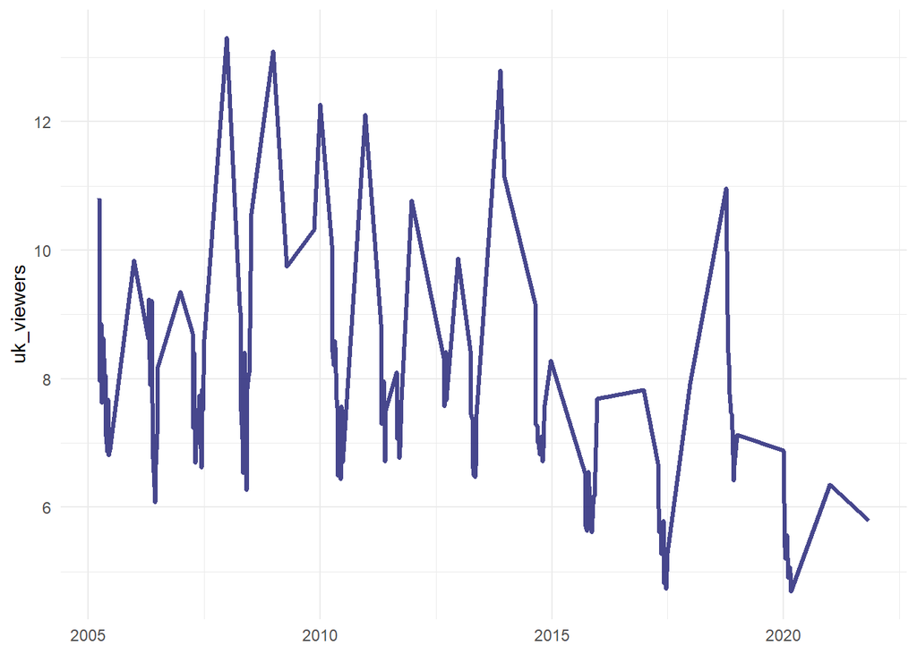

```r
episodes %>%
  ggplot(aes(first_aired, uk_viewers)) +
  geom_line(alpha = 0.8, size = 1.2, color = "#191970") +
  labs(x = NULL)
```

graph를 그려서 보면 첫 방송이후 떨어지다가 중간중간 스파이크처럼 솟아오르는 시기가 있는데 대부분 시즌 첫 화나 시즌 마지막 방송이다.  
스페셜 크리스마스 에피소드도 갑자기 솟아오르는 방송회차이다.  
전체적으로는 점차 시청자 수가 감소하는 경향을 보인다.

## Create a workflow

데이터 셋이 167행으로 매우 작은 데이터이기 때문에 부트스트랩을 사용한다.  
부트스트랩한 결과를 보면 analysis에 167행을 다 쓰고 61 ~ 55개 정도의 데이터를 assessment에 쓰도록 배분한 것을 확인할 수 있다.

```r
set.seed(123)

folds <- bootstraps(episodes, times = 100, strata = uk_viewers)

folds
```

| splits | id |
| --- | --- |
|  | Bootstrap001 |
|  | Bootstrap002 |
|  | Bootstrap003 |
|  | Bootstrap004 |
|  | Bootstrap005 |
|  | Bootstrap006 |
|  | Bootstrap007 |
|  | Bootstrap008 |
|  | Bootstrap009 |
|  | Bootstrap010 |

[output cut: 90 more lines]

여기서부터 feature engineering을 해 본다.  
- uk_viewers를 outcome으로, first_aired를 predictors로 하는 식을 `recipe()`에 만든다.  
- `step_date()`는 날짜 데이터를 하나 이상의 숫자형 변수나 factor로 변환하는데 argument로 들어가는 `features = ...`에 따라 변환하는 것이 달라진다.

- 도움말에서 `feature` aggument에 대한 설명을 보면 *A character string that includes at least one of the following values: month, dow (day of week), doy (day of year), week, month, decimal (decimal date, e.g. 2002.197), quarter, semester, year.*으로 되어 있다.

```r
who_recipe_juice <-
  recipe(uk_viewers ~ first_aired, data = episodes) %>%
  step_date(first_aired, features = "year") %>%
  prep() %>% juice()

who_recipe_juice
```

| first_aired | uk_viewers | first_aired_year |
| --- | --- | --- |
| 2005-03-26 | 10.81 | 2005 |
| 2005-04-02 | 7.97 | 2005 |
| 2005-04-09 | 8.86 | 2005 |
| 2005-04-16 | 7.63 | 2005 |
| 2005-04-23 | 7.98 | 2005 |
| 2005-04-30 | 8.63 | 2005 |
| 2005-05-07 | 8.01 | 2005 |
| 2005-05-14 | 8.06 | 2005 |
| 2005-05-21 | 7.11 | 2005 |
| 2005-05-28 | 6.86 | 2005 |

[output cut: 157 more lines]

- `step_date()`가 제대로 되었는지 확인하기 위해 `recipe()`를 `prep()`하여 `juice()`해 보면 아래와 같은 결과를 얻을 수 있다.
- 입력한대로 first_aired의 date 값을 가지고 와서 `featers = "year"` argument를 넣은대로 년도만 숫자형 변수로 추출한 것을 확인할 수 있다.
- argument로 `keep_original_cols`를 설정 할 수 있는데 이걸 TRUE로 두면 `step_date()`로 처리한 원래 열을 그대로 두고, FALSE일 경우에는 삭제한다. 지금은 first_aired열을 한 번 더 이용해야 하기 때문에 default값인 TRUE로 둔다.

```r
who_recipe_juice <-
  recipe(uk_viewers ~ first_aired, data = episodes) %>%
  step_holiday(first_aired,
               holidays = c("NewYearsDay", "ChristmasDay"),
               keep_original_cols = FALSE) %>%
  prep() %>% juice()

who_recipe_juice
```

| uk_viewers | first_aired_NewYearsDay | first_aired_ChristmasDay |
| --- | --- | --- |
| 10.81 | 0 | 0 |
| 7.97 | 0 | 0 |
| 8.86 | 0 | 0 |
| 7.63 | 0 | 0 |
| 7.98 | 0 | 0 |
| 8.63 | 0 | 0 |
| 8.01 | 0 | 0 |
| 8.06 | 0 | 0 |
| 7.11 | 0 | 0 |
| 6.86 | 0 | 0 |

[output cut: 157 more lines]

- `step_holiday()`로 “NewYearsDay”, “ChristmasDay”를 구별할 수 있게 한다.
- step_holiday()를 사용하여 NewYearsDay와 ChristmasDay를 0, 1로 구별하는 열을 생성한다.
- step_holiday()에서 사용가능한 holiday pattern은 https://rdrr.io/cran/timeDate/man/holiday-Listing.html에서 확인할 수 있다.
- `keep_original_cols = FALSE` 로 설정했기 때문에 first_aired 열은 삭제되었다.

```r
who_recipe <-
  recipe(uk_viewers ~ first_aired, data = episodes) %>%
  step_date(first_aired, features = "year") %>%
  step_holiday(first_aired,
               holidays = c("NewYearsDay", "ChristmasDay"),
               keep_original_cols = FALSE)

who_recipe
```

```
## Recipe
##
## Inputs:
##
##       role #variables
##    outcome          1
##  predictor          1
##
## Operations:
##
## Date features from first_aired
## Holiday features from first_aired
```

- recipe를 열어보면 `Date features from first_aired` 와 `Holiday features from first_aired` 두 개의 feature가 생성되었음을 알 수 있다.
- `prep()`을 이용해서 recipe를 training시킨다. *For a recipe with at least one preprocessing operation, estimate the required parameters from a training set that can be later applied to other data sets.*
- `bake()`를 이용해서 trained recipe를 가져와서 new_data에 계산을 적용하는데 NULL로 넣었기 때문에 데이터를 그대로 출력한다. *For a recipe with at least one preprocessing operation that has been trained by prep.recipe(), apply the computations to new data.*

```r
prep(who_recipe) %>% bake(new_data = NULL)
```

| uk_viewers | first_aired_year | first_aired_NewYearsDay | first_aired_ChristmasDay |
| --- | --- | --- | --- |
| 10.81 | 2005 | 0 | 0 |
| 7.97 | 2005 | 0 | 0 |
| 8.86 | 2005 | 0 | 0 |
| 7.63 | 2005 | 0 | 0 |
| 7.98 | 2005 | 0 | 0 |
| 8.63 | 2005 | 0 | 0 |
| 8.01 | 2005 | 0 | 0 |
| 8.06 | 2005 | 0 | 0 |
| 7.11 | 2005 | 0 | 0 |
| 6.86 | 2005 | 0 | 0 |

[output cut: 157 more lines]

- 여기서부터 `workflow()`를 만든다.

```r
who_wf <-
  workflow(who_recipe, linear_reg())

who_wf
```

```
## == Workflow ====================================================================
## Preprocessor: Recipe
## Model: linear_reg()
##
## -- Preprocessor ----------------------------------------------------------------
## 2 Recipe Steps
##
## * step_date()
## * step_holiday()
##
## -- Model -----------------------------------------------------------------------
## Linear Regression Model Specification (regression)
##
## Computational engine: lm
```

## Extract from resampled workflows

**중요**

```r
ctrl_extract <-
  control_resamples(extract = extract_fit_engine)

ctrl_extract
```

```
## grid/resamples control object
```

- `control_resamples()`에 `extract` argument를 extract_fit_engine으로 설정하면 결과에 .extracts 열이 생성된다.

```r
doParallel::registerDoParallel()

set.seed(234)
who_rs <-
  fit_resamples(who_wf, folds, control = ctrl_extract)

who_rs
```

| splits | id | .metrics | .notes | .extracts |
| --- | --- | --- | --- | --- |
|  | Bootstrap001 |  |  |  |
|  | Bootstrap002 |  |  |  |
|  | Bootstrap003 |  |  |  |
|  | Bootstrap004 |  |  |  |
|  | Bootstrap005 |  |  |  |
|  | Bootstrap006 |  |  |  |
|  | Bootstrap007 |  |  |  |
|  | Bootstrap008 |  |  |  |
|  | Bootstrap009 |  |  |  |
|  | Bootstrap010 |  |  |  |

[output cut: 90 more lines]

- .extracts만 따로 빼낸다.

```r
show1 <- who_rs %>% select(id, .extracts)
show1
```

| id | .extracts |
| --- | --- |
| Bootstrap001 |  |
| Bootstrap002 |  |
| Bootstrap003 |  |
| Bootstrap004 |  |
| Bootstrap005 |  |
| Bootstrap006 |  |
| Bootstrap007 |  |
| Bootstrap008 |  |
| Bootstrap009 |  |
| Bootstrap010 |  |

[output cut: 90 more lines]

- .extracts는 1(행) x 2(열)로 구성된 list인데 이를 `unnest()`를 사용하여 풀면 .extracts열과 .config열이 나타남을 볼 수 있다.

```r
show2 <- show1 %>% unnest(.extracts)
show2
```

| id | .extracts | .config |
| --- | --- | --- |
| Bootstrap001 |  | Preprocessor1_Model1 |
| Bootstrap002 |  | Preprocessor1_Model1 |
| Bootstrap003 |  | Preprocessor1_Model1 |
| Bootstrap004 |  | Preprocessor1_Model1 |
| Bootstrap005 |  | Preprocessor1_Model1 |
| Bootstrap006 |  | Preprocessor1_Model1 |
| Bootstrap007 |  | Preprocessor1_Model1 |
| Bootstrap008 |  | Preprocessor1_Model1 |
| Bootstrap009 |  | Preprocessor1_Model1 |
| Bootstrap010 |  | Preprocessor1_Model1 |

[output cut: 90 more lines]

- `coefs`열을 만드는데 .extracts에 있는 을 `tidy()` 한다. 그러면 coefs에는 4(행) x 5(열)의 데이터 프레임을 가지는 리스트 열이 생성된다.

```r
show3 <- show2 %>% mutate(coefs = map(.extracts, tidy))
show3
```

| id | .extracts | .config | coefs |
| --- | --- | --- | --- |
| Bootstrap001 |  | Preprocessor1_Model1 |  |
| Bootstrap002 |  | Preprocessor1_Model1 |  |
| Bootstrap003 |  | Preprocessor1_Model1 |  |
| Bootstrap004 |  | Preprocessor1_Model1 |  |
| Bootstrap005 |  | Preprocessor1_Model1 |  |
| Bootstrap006 |  | Preprocessor1_Model1 |  |
| Bootstrap007 |  | Preprocessor1_Model1 |  |
| Bootstrap008 |  | Preprocessor1_Model1 |  |
| Bootstrap009 |  | Preprocessor1_Model1 |  |
| Bootstrap010 |  | Preprocessor1_Model1 |  |

[output cut: 90 more lines]

- lm model을 tidy한 결과로 각 예측변수(year, NewYearsDay, ChristmasDay, (Intercept) - 4개)에 대한 term, estimate, std.error, statistic, p.value의 5개의 계산값이 들어 있는 열이 생성되었다.

```r
show4 <- show3 %>% unnest(coefs)
show4
```

| id | .extracts | .config | term | estimate | std.error | statistic | p.value |
| --- | --- | --- | --- | --- | --- | --- | --- |
| Bootstrap001 |  | Preprocessor1_Model1 | (Intercept) | 311.0268465 | 37.96229158 | 8.1930472 | 7.073359e-14 |
| Bootstrap001 |  | Preprocessor1_Model1 | first_aired_year | -0.1509987 | 0.01887038 | -8.0018876 | 2.167902e-13 |
| Bootstrap001 |  | Preprocessor1_Model1 | first_aired_NewYearsDay | 0.6860219 | 0.81237960 | 0.8444598 | 3.996502e-01 |
| Bootstrap001 |  | Preprocessor1_Model1 | first_aired_ChristmasDay | 2.7870674 | 0.30275544 | 9.2056721 | 1.603903e-16 |
| Bootstrap002 |  | Preprocessor1_Model1 | (Intercept) | 341.6954561 | 41.32313539 | 8.2688657 | 4.523331e-14 |
| Bootstrap002 |  | Preprocessor1_Model1 | first_aired_year | -0.1662605 | 0.02054301 | -8.0932895 | 1.270674e-13 |
| Bootstrap002 |  | Preprocessor1_Model1 | first_aired_NewYearsDay | 2.1799001 | 0.70879019 | 3.0755224 | 2.464803e-03 |
| Bootstrap002 |  | Preprocessor1_Model1 | first_aired_ChristmasDay | 3.1379253 | 0.32570148 | 9.6343598 | 1.141101e-17 |
| Bootstrap003 |  | Preprocessor1_Model1 | (Intercept) | 286.2435104 | 44.09175273 | 6.4919966 | 9.757349e-10 |
| Bootstrap003 |  | Preprocessor1_Model1 | first_aired_year | -0.1386398 | 0.02191362 | -6.3266503 | 2.319483e-09 |

[output cut: 390 more lines]

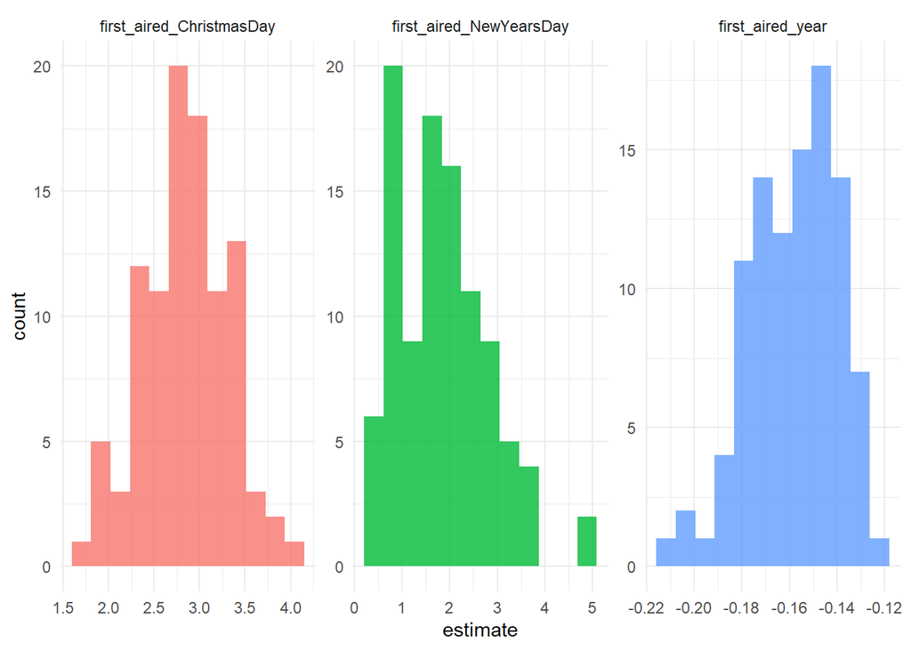

```r
who_rs %>%
  select(id, .extracts) %>%
  unnest(.extracts) %>%
  mutate(coefs = map(.extracts, tidy)) %>%
  unnest(coefs) %>%
  filter(term != "(Intercept)") %>%
  ggplot(aes(estimate, fill = term)) +
  geom_histogram(alpha = 0.8, bins = 12, show.legend = FALSE) +
  facet_wrap(vars(term), scales = "free")
```

- 이 예제에서 중요한 것은 `control_resamples(extract = extract_fit_engine)`를 사용해서 필요한 것은 무엇이든 모델에서 추출할 수 있다는 것이다.

**END**